# Week 1

# Importing libraries

```python
import pandas as pd
import seaborn as sns
import matplotlib.pyplot as plt
import numpy as np
%matplotlib inline
```

```python
#Imorting data
data = pd.read_csv('health care diabetes.csv')
```

```python
# Reading data
data.head()
```

|  | Pregnancies | Glucose | BloodPressure | SkinThickness | Insulin | BMI | DiabetesPedigreeFunction | Age | Outcome |
| --- | --- | --- | --- | --- | --- | --- | --- | --- | --- |
| 0 | 6 | 148 | 72 | 35 | 0 | 33.6 | 0.627 | 50 | 1 |
| 1 | 1 | 85 | 66 | 29 | 0 | 26.6 | 0.351 | 31 | 0 |
| 2 | 8 | 183 | 64 | 0 | 0 | 23.3 | 0.672 | 32 | 1 |
| 3 | 1 | 89 | 66 | 23 | 94 | 28.1 | 0.167 | 21 | 0 |
| 4 | 0 | 137 | 40 | 35 | 168 | 43.1 | 2.288 | 33 | 1 |

```python
data.tail()
```

|  | Pregnancies | Glucose | BloodPressure | SkinThickness | Insulin | BMI | DiabetesPedigreeFunction | Age | Outcome |
| --- | --- | --- | --- | --- | --- | --- | --- | --- | --- |
| 763 | 10 | 101 | 76 | 48 | 180 | 32.9 | 0.171 | 63 | 0 |
| 764 | 2 | 122 | 70 | 27 | 0 | 36.8 | 0.340 | 27 | 0 |
| 765 | 5 | 121 | 72 | 23 | 112 | 26.2 | 0.245 | 30 | 0 |
| 766 | 1 | 126 | 60 | 0 | 0 | 30.1 | 0.349 | 47 | 1 |
| 767 | 1 | 93 | 70 | 31 | 0 | 30.4 | 0.315 | 23 | 0 |

# Exploring data

```python
data.info()
```

```
<class 'pandas.core.frame.DataFrame'>
RangeIndex: 768 entries, 0 to 767
Data columns (total 9 columns):
 #   Column                    Non-Null Count  Dtype
---  ------                    --------------  -----
 0   Pregnancies               768 non-null    int64
 1   Glucose                   768 non-null    int64
 2   BloodPressure             768 non-null    int64
 3   SkinThickness             768 non-null    int64
 4   Insulin                   768 non-null    int64
 5   BMI                       768 non-null    float64
 6   DiabetesPedigreeFunction  768 non-null    float64
 7   Age                       768 non-null    int64
 8   Outcome                   768 non-null    int64
dtypes: float64(2), int64(7)
memory usage: 54.1 KB
```

```python
#Finding missing values
data.describe()
```

|  | Pregnancies | Glucose | BloodPressure | SkinThickness | Insulin | BMI | DiabetesPedigreeFunction | Age | Outcome |
| --- | --- | --- | --- | --- | --- | --- | --- | --- | --- |
| count | 768.000000 | 768.000000 | 768.000000 | 768.000000 | 768.000000 | 768.000000 | 768.000000 | 768.000000 | 768.000000 |
| mean | 3.845052 | 120.894531 | 69.105469 | 20.536458 | 79.799479 | 31.992578 | 0.471876 | 33.240885 | 0.348958 |
| std | 3.369578 | 31.972618 | 19.355807 | 15.952218 | 115.244002 | 7.884160 | 0.331329 | 11.760232 | 0.476951 |
| min | 0.000000 | 0.000000 | 0.000000 | 0.000000 | 0.000000 | 0.000000 | 0.078000 | 21.000000 | 0.000000 |
| 25% | 1.000000 | 99.000000 | 62.000000 | 0.000000 | 0.000000 | 27.300000 | 0.243750 | 24.000000 | 0.000000 |
| 50% | 3.000000 | 117.000000 | 72.000000 | 23.000000 | 30.500000 | 32.000000 | 0.372500 | 29.000000 | 0.000000 |
| 75% | 6.000000 | 140.250000 | 80.000000 | 32.000000 | 127.250000 | 36.600000 | 0.626250 | 41.000000 | 1.000000 |
| max | 17.000000 | 199.000000 | 122.000000 | 99.000000 | 846.000000 | 67.100000 | 2.420000 | 81.000000 | 1.000000 |

```python
data.shape
```

```
(768, 9)
```

```python
data.dtypes
```

```
Pregnancies                   int64
Glucose                       int64
BloodPressure                 int64
SkinThickness                 int64
Insulin                       int64
BMI                         float64
DiabetesPedigreeFunction    float64
Age                           int64
Outcome                       int64
dtype: object
```

# Data Cleaning

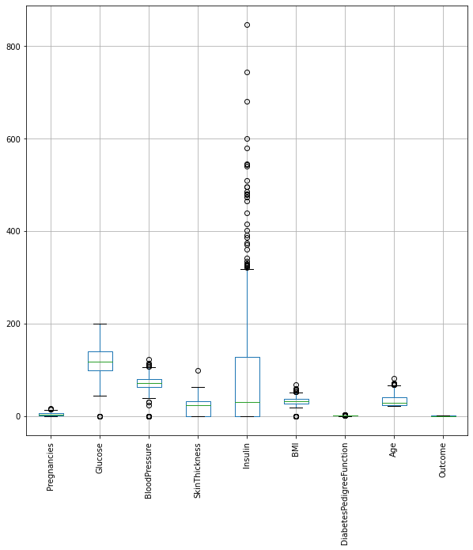

```python
data.boxplot(figsize=(10,10), rot=90)
```

[output not shown]

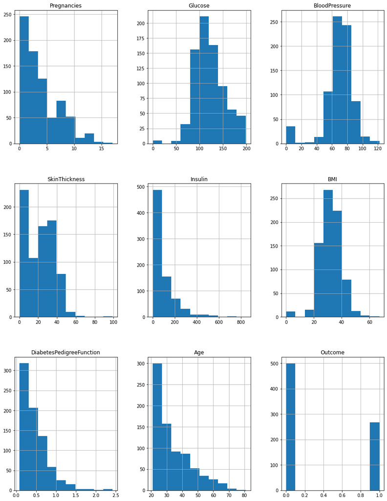

```python
data.hist(figsize=(15,20))
```

```python
not_allowed_zero_cols = ['Glucose', 'BloodPressure', 'SkinThickness', 'Insulin', 'BMI']
data = data
```

```python
data[not_allowed_zero_cols] = data[not_allowed_zero_cols].replace(0, np.NaN)
```

```python
import warnings
warnings.filterwarnings('ignore')
```

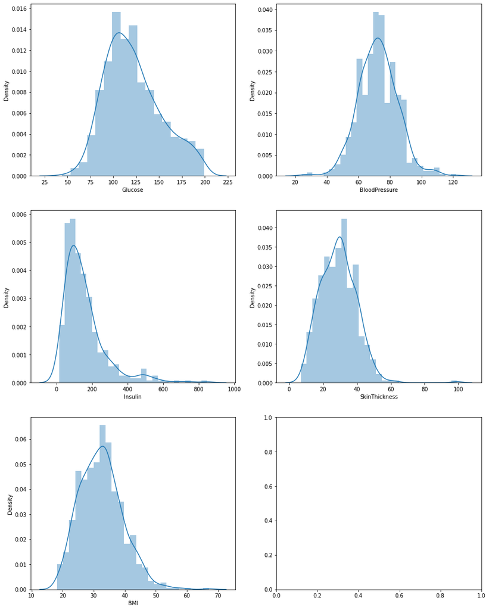

```python
fig, ax = plt.subplots(nrows=3, ncols=2, figsize=(15,20))
sns.distplot(data.Glucose, ax=ax[0][0])
sns.distplot(data.BloodPressure, ax=ax[0][1])
sns.distplot(data.Insulin, ax=ax[1][0])
sns.distplot(data.SkinThickness, ax=ax[1][1])
sns.distplot(data.BMI, ax=ax[2][0])
```

```python
data['Glucose'].fillna(data.Glucose.mean(), inplace=True)
data['BloodPressure'].fillna(data.BloodPressure.mean(), inplace=True)
data['BMI'].fillna(data.BMI.mean(), inplace=True)
data['SkinThickness'].fillna(data.SkinThickness.mean(), inplace=True)

data['Insulin'].fillna(data.Insulin.median(), inplace=True)
```

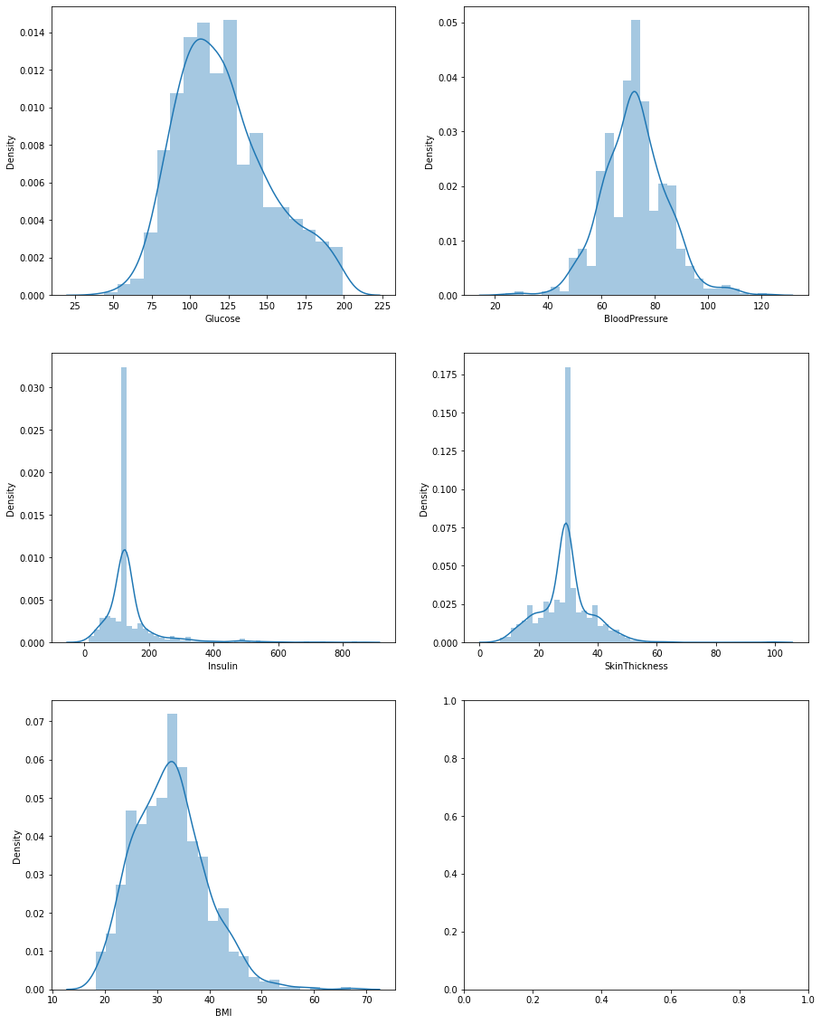

```python
fig, ax = plt.subplots(nrows=3, ncols=2, figsize=(15,20))
sns.distplot(data.Glucose, ax=ax[0][0])
sns.distplot(data.BloodPressure, ax=ax[0][1])
sns.distplot(data.Insulin, ax=ax[1][0])
sns.distplot(data.SkinThickness, ax=ax[1][1])
sns.distplot(data.BMI, ax=ax[2][0])
```

# Observations

## Exploratory Data Analysis:

### Age, Insulin, DiabetesPedigreeFunction and Pregnancies are right skewed.

### Zero values in blood pressure, BMI, Insulin and Glocuse clearly stands out in the plot

### After removing zeros for non-zero expected columns, we see that except Insulin which is highly right skewed, all other are near to gaussian distribution.

### Except for Insulin, for rest of other non-zero columns, we can take mean value.

### For Insulin, we took median value to fill

# Plot data types

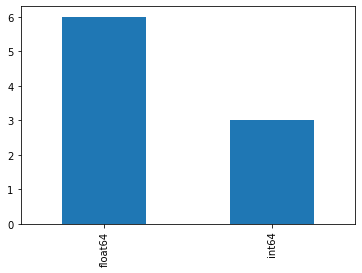

```python
data.dtypes.value_counts().plot(kind='bar')
```

# Pair plot analysis

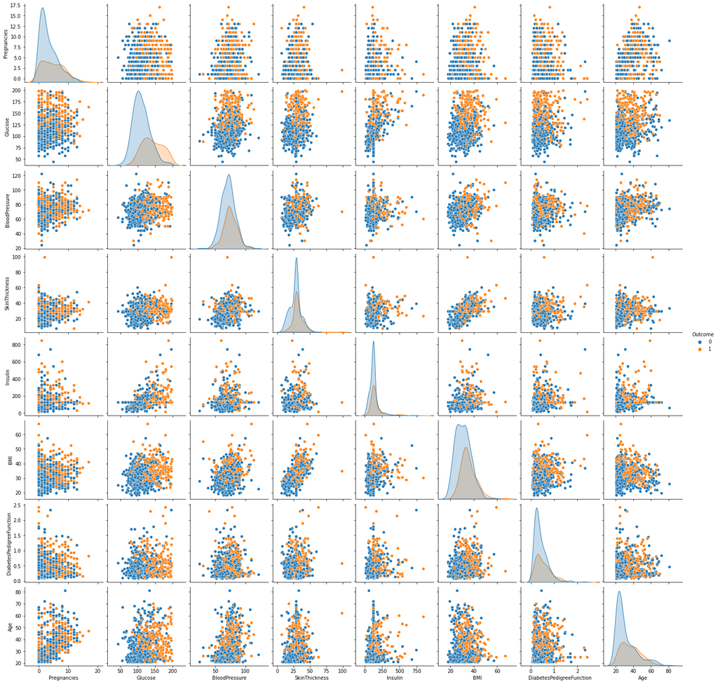

```python
sns.pairplot(data, hue='Outcome')
```

# Correlation analysis

```python
cor = data.corr()
mask = np.triu(np.ones_like(cor, dtype=np.bool))
```

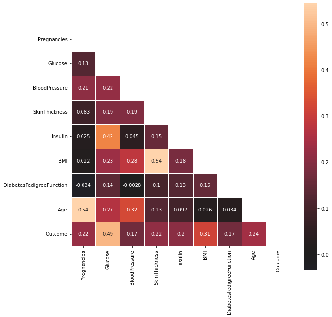

```python
plt.figure(figsize=(10,10))
sns.heatmap(cor, mask=mask, center=0,
            square=True, linewidths=.5, annot=True)
```

# Observations

## Correlation Analysis

### Outcome is moderately correlated to Glucose

# Week 2

## Scaling and splitting the data

```python
from sklearn.model_selection import train_test_split
from sklearn.metrics import classification_report, f1_score, accuracy_score, mean_squared_error, roc_auc_score, confusion_matrix, roc_curve, recall_score, precision_score, f1_score
from sklearn.preprocessing import StandardScaler
```

```python
X_scaled = StandardScaler().fit_transform(data.drop(['Outcome'], axis='columns'))
```

```python
X_train, X_test, y_train, y_test = train_test_split(X_scaled, data.Outcome, random_state=123, test_size=.2)
```

# Logistic Regression

```python
from sklearn.linear_model import LogisticRegression
```

```python
lr_clf= LogisticRegression(class_weight='balanced', random_state=123, max_iter=500)
```

```python
lr_clf.fit(X_train, y_train)
```

```
LogisticRegression(class_weight='balanced', max_iter=500, random_state=123)
```

```python
lr_pred = lr_clf.predict(X_test)
```

```python
lr_model_vals = dict(accuracy=accuracy_score(y_test, lr_pred),
                    auc=roc_auc_score(y_test, lr_pred),
                    recall=recall_score(y_test, lr_pred),
                    precision=precision_score(y_test, lr_pred),
                    f1_score = f1_score(y_test, lr_pred),
                    )
```

```python
y_pred_prob_lr = lr_clf.predict_proba(X_test)[:, 1]
fpr_lr, tpr_lr , th_lr = roc_curve(y_test, y_pred_prob_lr)
gmean_lr = np.sqrt(tpr_lr * (1-fpr_lr))
ix_lr = np.argmax(gmean_lr)
```

```python
th_lr[np.argmax(gmean_lr)]
```

```
0.36454228797001864
```

```python
y_roc_pred_lr = [0 if pred < th_lr[ix_lr] else 1 for pred in y_pred_prob_lr ]
```

```python
print("Test classification Report With  tuned threshold")
print(classification_report(y_test, y_roc_pred_lr)  )

print("Test classification Report Without  tuned threshold")
print(classification_report(y_test, lr_pred) )
```

```
Test classification Report With  tuned threshold
              precision    recall  f1-score   support

           0       0.94      0.66      0.77        96
           1       0.62      0.93      0.74        58

    accuracy                           0.76       154
   macro avg       0.78      0.79      0.76       154
weighted avg       0.82      0.76      0.76       154

Test classification Report Without  tuned threshold
              precision    recall  f1-score   support

           0       0.83      0.79      0.81        96
           1       0.68      0.72      0.70        58

    accuracy                           0.77       154
   macro avg       0.75      0.76      0.75       154
weighted avg       0.77      0.77      0.77       154
```

```python
fpr_tlr, tpr_tlr , th_tlr = roc_curve(y_test, y_roc_pred_lr)
gmean_tlr = np.sqrt(tpr_tlr * (1-fpr_tlr))
ix_tlr = np.argmax(gmean_tlr)
```

```python
tlr_model_vals = dict(accuracy=accuracy_score(y_test, y_roc_pred_lr),
                    auc=roc_auc_score(y_test, y_roc_pred_lr),
                    recall=recall_score(y_test, y_roc_pred_lr),
                    precision=precision_score(y_test, y_roc_pred_lr),
                    f1_score = f1_score(y_test, y_roc_pred_lr),
                    )
```

# Naive Bayes Classificaiton

```python
from sklearn.naive_bayes import GaussianNB
```

```python
gnb_clf = GaussianNB()
```

```python
gnb_clf.fit(X_train, y_train)
```

```
GaussianNB()
```

```python
gnb_pred = gnb_clf.predict(X_test)
```

```python
gnb_model_vals = dict(accuracy=accuracy_score(y_test, gnb_pred),
                    auc=roc_auc_score(y_test, gnb_pred),
                    recall=recall_score(y_test, gnb_pred),
                    precision=precision_score(y_test, gnb_pred),
                    f1_score = f1_score(y_test, gnb_pred),
                    )
```

```python
y_pred_prob_gnb = gnb_clf.predict_proba(X_test)[:, 1]
fpr_nb, tpr_nb , th_nb = roc_curve(y_test, y_pred_prob_gnb)
gmean_nb = np.sqrt(tpr_nb * (1-fpr_nb))
ix_nb = np.argmax(gmean_nb)
```

```python
print("Train Classification Report")
print(classification_report(y_train, gnb_clf.predict(X_train))  )
```

```
Train Classification Report
              precision    recall  f1-score   support

           0       0.79      0.83      0.81       404
           1       0.64      0.59      0.61       210

    accuracy                           0.74       614
   macro avg       0.72      0.71      0.71       614
weighted avg       0.74      0.74      0.74       614
```

```python
print("Test Classification Report")
print(classification_report(y_test, gnb_clf.predict(X_test))  )
```

```
Test Classification Report
              precision    recall  f1-score   support

           0       0.79      0.83      0.81        96
           1       0.70      0.64      0.67        58

    accuracy                           0.76       154
   macro avg       0.75      0.74      0.74       154
weighted avg       0.76      0.76      0.76       154
```

# Random Forest

```python
from sklearn.ensemble import RandomForestClassifier
```

```python
rf_clf = RandomForestClassifier()
```

```python
rf_clf.fit(X_train, y_train)
```

```
RandomForestClassifier()
```

```python
rf_pred = rf_clf.predict(X_test)
```

```python
rf_model_vals = dict(accuracy=accuracy_score(y_test, rf_pred),
                    auc=roc_auc_score(y_test, rf_pred),
                    recall=recall_score(y_test, rf_pred),
                    precision=precision_score(y_test, rf_pred),
                    f1_score = f1_score(y_test, rf_pred),
                    )
```

```python
y_pred_prob_rf = rf_clf.predict_proba(X_test)[:, 1]
fpr_rf, tpr_rf , th_rf = roc_curve(y_test, y_pred_prob_rf)
gmean_rf = np.sqrt(tpr_rf * (1-fpr_rf))
ix_rf = np.argmax(gmean_rf)
```

```python
print("\t\tTrain Classification Report\n")
print(classification_report(y_train, rf_clf.predict(X_train))  )
```

```
		Train Classification Report

              precision    recall  f1-score   support

           0       1.00      1.00      1.00       404
           1       1.00      1.00      1.00       210

    accuracy                           1.00       614
   macro avg       1.00      1.00      1.00       614
weighted avg       1.00      1.00      1.00       614
```

```python
print("\t\tTest Classification Report\n")
print(classification_report(y_test, rf_clf.predict(X_test))  )
```

```
		Test Classification Report

              precision    recall  f1-score   support

           0       0.81      0.86      0.84        96
           1       0.75      0.67      0.71        58

    accuracy                           0.79       154
   macro avg       0.78      0.77      0.77       154
weighted avg       0.79      0.79      0.79       154
```

### Observation

```python
alphas=[]
test=[]
train=[]
for alpha in np.linspace(.03, .05, 10):
    rf = RandomForestClassifier(ccp_alpha=alpha, random_state=123)
    rf.fit(X_train, y_train)
    y_train_predicted = rf.predict(X_train)
    y_test_predicted = rf.predict(X_test)
    mse_train = mean_squared_error(y_train, y_train_predicted)
    mse_test = mean_squared_error(y_test, y_test_predicted)
    alphas.append(alpha)
    test.append(mse_test)
    train.append(mse_train)
    print("Alpha: {} Train mse: {} Test mse: {}".format(alpha, mse_train, mse_test))

score=pd.DataFrame({'alpha': alphas, 'test':test, 'train': train})
```

```
Alpha: 0.03 Train mse: 0.2719869706840391 Test mse: 0.2662337662337662
Alpha: 0.03222222222222222 Train mse: 0.2768729641693811 Test mse: 0.2792207792207792
Alpha: 0.034444444444444444 Train mse: 0.28338762214983715 Test mse: 0.2857142857142857
Alpha: 0.03666666666666667 Train mse: 0.2947882736156352 Test mse: 0.2857142857142857
Alpha: 0.03888888888888889 Train mse: 0.3241042345276873 Test mse: 0.35714285714285715
Alpha: 0.04111111111111111 Train mse: 0.34201954397394135 Test mse: 0.37662337662337664
Alpha: 0.043333333333333335 Train mse: 0.34201954397394135 Test mse: 0.37662337662337664
Alpha: 0.04555555555555556 Train mse: 0.34201954397394135 Test mse: 0.37662337662337664
Alpha: 0.04777777777777778 Train mse: 0.34201954397394135 Test mse: 0.37662337662337664
Alpha: 0.05 Train mse: 0.34201954397394135 Test mse: 0.37662337662337664
```

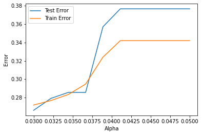

```python
plt.plot(score.alpha, score.test)
plt.plot(score.alpha, score.train)
plt.legend(['Test Error', 'Train Error'])
plt.xlabel('Alpha')
plt.ylabel('Error')
```

```python
from sklearn.model_selection import RandomizedSearchCV
```

```python
# Create the random grid
random_grid = { 'ccp_alpha': np.linspace(.03, .05, 10),
                'n_estimators': [int(x) for x in np.linspace(start = 200, stop = 1000, num = 5)],
               'max_features': ['auto', 'sqrt'],
               'max_depth': [int(x) for x in np.linspace(5, 55, num = 10)],
               'min_samples_split': [5, 10, 12],
               'min_samples_leaf': [3,5,7,10],
               }
```

```python
rf_clf_cv = RandomForestClassifier(class_weight="balanced", random_state=123)
rscv = RandomizedSearchCV(estimator=rf_clf_cv, param_distributions=random_grid, cv=3, scoring='f1_weighted')
```

```python
rscv.fit(X_train, y_train)
```

```
RandomizedSearchCV(cv=3,
                   estimator=RandomForestClassifier(class_weight='balanced',
                                                    random_state=123),
                   param_distributions={'ccp_alpha': array([0.03      , 0.03222222, 0.03444444, 0.03666667, 0.03888889,
       0.04111111, 0.04333333, 0.04555556, 0.04777778, 0.05      ]),
                                        'max_depth': [5, 10, 16, 21, 27, 32, 38,
                                                      43, 49, 55],
                                        'max_features': ['auto', 'sqrt'],
                                        'min_samples_leaf': [3, 5, 7, 10],
                                        'min_samples_split': [5, 10, 12],
                                        'n_estimators': [200, 400, 600, 800,
                                                         1000]},
                   scoring='f1_weighted')
```

```python
rscv.best_estimator_
```

```
RandomForestClassifier(ccp_alpha=0.03666666666666667, class_weight='balanced',
                       max_depth=32, max_features='auto', min_samples_leaf=5,
                       min_samples_split=10, n_estimators=600,
                       random_state=123)
```

```python
print("\t\tTest Classification Report\n")
print(classification_report(y_test, rscv.predict(X_test))  )
```

```
		Test Classification Report

              precision    recall  f1-score   support

           0       0.86      0.78      0.82        96
           1       0.69      0.79      0.74        58

    accuracy                           0.79       154
   macro avg       0.77      0.79      0.78       154
weighted avg       0.80      0.79      0.79       154
```

```python
print("\t\tTrain Classification Report\n")
print(classification_report(y_train, rscv.predict(X_train))  )
```

```
		Train Classification Report

              precision    recall  f1-score   support

           0       0.87      0.77      0.82       404
           1       0.64      0.78      0.70       210

    accuracy                           0.77       614
   macro avg       0.75      0.77      0.76       614
weighted avg       0.79      0.77      0.78       614
```

```python
tuned_rf_model_vals = dict(accuracy=accuracy_score(y_test, rscv.predict(X_test)),
                    auc=roc_auc_score(y_test, rscv.predict(X_test)),
                    recall=recall_score(y_test, rscv.predict(X_test)),
                    precision=precision_score(y_test, rscv.predict(X_test)),
                    f1_score = f1_score(y_test, rscv.predict(X_test)),
                    )
```

```python
y_pred_prob_trf = rscv.predict_proba(X_test)[:, 1]
fpr_trf, tpr_trf , th_trf = roc_curve(y_test, y_pred_prob_trf)
gmean_trf = np.sqrt(tpr_trf * (1-fpr_trf))
ix_trf = np.argmax(gmean_trf)
```

```python
import sklearn.metrics
sorted(sklearn.metrics.SCORERS.keys())
```

```
['accuracy',
 'adjusted_mutual_info_score',
 'adjusted_rand_score',
 'average_precision',
 'balanced_accuracy',
 'completeness_score',
 'explained_variance',
 'f1',
 'f1_macro',
 'f1_micro',
 'f1_samples',
 'f1_weighted',
 'fowlkes_mallows_score',
 'homogeneity_score',
 'jaccard',
 'jaccard_macro',
 'jaccard_micro',
 'jaccard_samples',
 'jaccard_weighted',
 'matthews_corrcoef',
 'max_error',
 'mutual_info_score',
 'neg_brier_score',
 'neg_log_loss',
 'neg_mean_absolute_error',
 'neg_mean_absolute_percentage_error',
 'neg_mean_gamma_deviance',
 'neg_mean_poisson_deviance',
 'neg_mean_squared_error',
 'neg_mean_squared_log_error',
 'neg_median_absolute_error',
 'neg_negative_likelihood_ratio',
 'neg_root_mean_squared_error',
 'normalized_mutual_info_score',
 'positive_likelihood_ratio',
 'precision',
 'precision_macro',
 'precision_micro',
 'precision_samples',
 'precision_weighted',
 'r2',
 'rand_score',
 'recall',
 'recall_macro',
 'recall_micro',
 'recall_samples',
 'recall_weighted',
 'roc_auc',
 'roc_auc_ovo',
 'roc_auc_ovo_weighted',
 'roc_auc_ovr',
 'roc_auc_ovr_weighted',
 'top_k_accuracy',
 'v_measure_score']
```

# Observation

### I have done several iterations and compared trin and test errors to arrive at optimum cost value.

# K-Nearest Neighbour

```python
from sklearn.neighbors import KNeighborsClassifier
```

```python
nbr = []
error_rmse = []
error_rate = []
accuracy = []
for n in range(2, 50):
    knn_clf = KNeighborsClassifier(n_neighbors=n, weights='distance')
    knn_clf.fit(X_train, y_train)
    pred = knn_clf.predict(X_test)

    nbr.append(n)
    error_rmse.append(mean_squared_error(y_test, pred, squared=False))
    error_rate.append(np.mean(y_test != pred))
    accuracy.append(accuracy_score(y_test, pred))

knn_stats = pd.DataFrame({'neighbour': nbr, 'rmse': error_rmse, 'error_rate': error_rate, 'accuracy': accuracy})
```

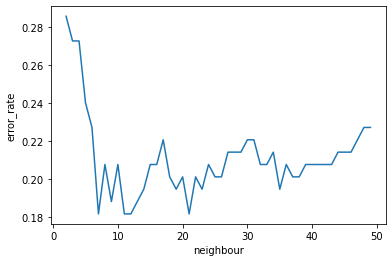

```python
sns.lineplot(x='neighbour', y='error_rate', data=knn_stats)
```

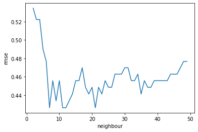

```python
sns.lineplot(x='neighbour', y='rmse', data=knn_stats)
```

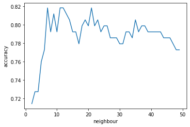

```python
sns.lineplot(x='neighbour', y='accuracy', data=knn_stats)
```

```python
knn_stats.neighbour[knn_stats.rmse.argmin()]
```

```
7
```

```python
knn_stats.neighbour[[5,19,9,10]]
```

```
5      7
19    21
9     11
10    12
Name: neighbour, dtype: int64
```

```python
knn_clf = KNeighborsClassifier(n_neighbors=7, weights='distance')
knn_clf.fit(X_train, y_train)
knn_pred = knn_clf.predict(X_test)
```

```python
print(classification_report(y_test, pred))
```

```
              precision    recall  f1-score   support

           0       0.77      0.91      0.83        96
           1       0.78      0.55      0.65        58

    accuracy                           0.77       154
   macro avg       0.78      0.73      0.74       154
weighted avg       0.77      0.77      0.76       154
```

```python
knn_model_vals = dict(accuracy=accuracy_score(y_test, knn_pred),
                    auc=roc_auc_score(y_test, knn_pred),
                    recall=recall_score(y_test, knn_pred),
                    precision=precision_score(y_test, knn_pred),
                    f1_score = f1_score(y_test, knn_pred),
                    )
```

```python
y_pred_prob_knn = knn_clf.predict_proba(X_test)[:, 1]
fpr_knn, tpr_knn , th_knn = roc_curve(y_test, y_pred_prob_knn)
gmean_knn = np.sqrt(tpr_knn * (1-fpr_knn))
ix_knn = np.argmax(gmean_knn)
```

## Tuning KNN

```python
knn_param_grid = {'n_neighbors' : [7, 11, 12, 21],
                      'weights': ['distance', 'uniform'],
                      'algorithm' : ['ball_tree', 'kd_tree'],
                     'leaf_size' :[30,40,50],
                 }
```

```python
knn_rscv = RandomizedSearchCV(estimator=KNeighborsClassifier(), param_distributions=knn_param_grid, cv=3, scoring='f1_weighted')
```

```python
knn_rscv.fit(X_train, y_train)
```

```
RandomizedSearchCV(cv=3, estimator=KNeighborsClassifier(),
                   param_distributions={'algorithm': ['ball_tree', 'kd_tree'],
                                        'leaf_size': [30, 40, 50],
                                        'n_neighbors': [7, 11, 12, 21],
                                        'weights': ['distance', 'uniform']},
                   scoring='f1_weighted')
```

```python
knn_rscv.best_params_
```

```
{'weights': 'distance',
 'n_neighbors': 12,
 'leaf_size': 40,
 'algorithm': 'ball_tree'}
```

```python
tknn_pred = knn_rscv.predict(X_test)
```

```python
y_pred_prob_knn_cv = knn_rscv.predict_proba(X_test)[:, 1]
fpr_tknn, tpr_tknn , th_tknn = roc_curve(y_test, y_pred_prob_knn_cv)
gmean_tknn = np.sqrt(tpr_tknn * (1-fpr_tknn))
ix_tknn = np.argmax(gmean_tknn)
```

```python
accuracy_score(y_test, tknn_pred)
```

```
0.8181818181818182
```

```python
tknn_model_vals = dict(accuracy=accuracy_score(y_test, tknn_pred),
                    auc=roc_auc_score(y_test, tknn_pred),
                    recall=recall_score(y_test, tknn_pred),
                    precision=precision_score(y_test, tknn_pred),
                    f1_score = f1_score(y_test, tknn_pred),
                    )
```

# Model Comparison

## Data Modeling:

### Create a classification report by analyzing sensitivity, specificity, AUC (ROC curve), etc. Please be descriptive to explain what values of these parameter you have used.

## Observations

### I have plotted auc_roc curve of all the models together for comparison purpose. Also, I have plotted all the model stats together, tuned and non-tuned version. We can compare the performance by looking at the plots. Of that, I have selected 3 best tuned models and plotted again to show what model is best of the lot.

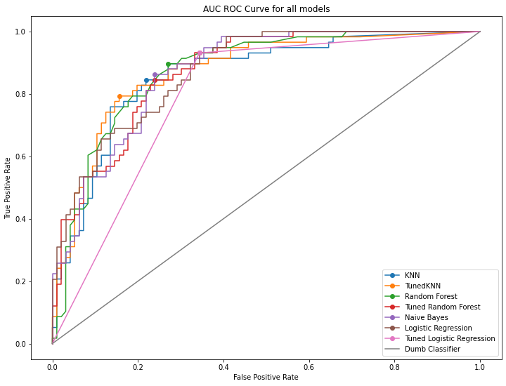

```python
plt.subplots(figsize=(12,9))
plt.plot(fpr_knn, tpr_knn, marker='o', markevery=[ix_knn])
plt.plot(fpr_tknn, tpr_tknn, marker='o', markevery=[ix_tknn])
plt.plot(fpr_rf, tpr_rf, marker='o', markevery=[ix_rf])
plt.plot(fpr_trf, tpr_trf, marker='o', markevery=[ix_trf])
plt.plot(fpr_nb, tpr_nb, marker='o', markevery=[ix_nb])
plt.plot(fpr_lr, tpr_lr, marker='o', markevery=[ix_lr])
plt.plot(fpr_tlr, tpr_tlr, marker='o', markevery=[ix_tlr])
plt.plot([0,1], [0,1])
plt.xlabel('False Positive Rate')
plt.ylabel('True Positive Rate')
plt.title('AUC ROC Curve for all models')
plt.legend(['KNN', 'TunedKNN', 'Random Forest', 'Tuned Random Forest', 'Naive Bayes', 'Logistic Regression',  'Tuned Logistic Regression','Dumb Classifier'])
plt.show()
```

```python
model_stats = pd.DataFrame(data=[lr_model_vals, tlr_model_vals, gnb_model_vals, rf_model_vals,
                                 tuned_rf_model_vals, knn_model_vals, tknn_model_vals ],
                           index=['LogReg', 'Tuned LogReg auc_roc', 'naive_bayes', 'random_forest',
                                  'tuned_random_forest ', 'knn', 'tuned knn'])
```

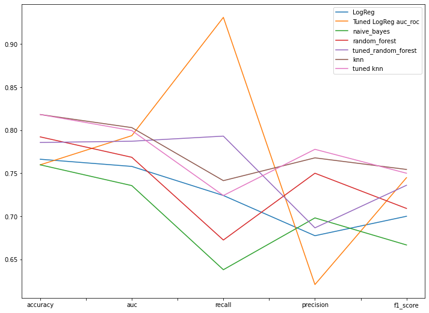

```python
model_stats.T.plot(kind='line', figsize=(12,9))
```

# Final Model

```python
final_models = pd.DataFrame(data=[ tlr_model_vals, tuned_rf_model_vals,  tknn_model_vals ],
                           index=['Logistic Regression',  'Random Forest', 'KNN'])
```

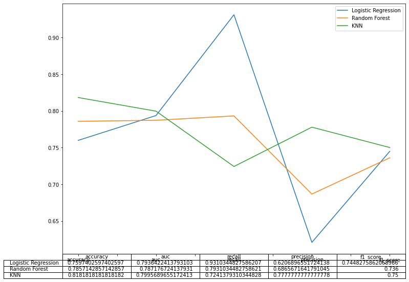

```python
final_models.T.plot(kind='line', figsize=(12,9), table=True)
```

# Capstone Project by Amaan Baig